# Expertenbefragung

Erik Marx

2024-07-26

In diesem Bericht wollen wir die Daten auswerten, die in der Expertenbefragung der dritten Version des Fragebogens erhoben wurden. Diese sind bereits alle in “answers_raw_new.xlsx” zuusammengefasst.

# Score berechnen

Es gibt verschiedene Möglichkeiten die Antworten zu scoren. Für diese Befragung kommen vor allem drei Varianten in Frage.

**Standardverfahren**

- Antworten werden Itemweise, also für jede Antwort betrachtet
- Für jede richtige Antwort gibt es einen Punkt. Für Falschantworten gibt es keine Punkte, aber auch keine Abzüge.
- Gesamtzahl der erreichten Punkte im Fragebogen ist damit normalverteilt (wenn Fähigkeiten der Befragten normalverteilt).

**Formula Scoring**

- Antworten werden Itemweise ausgewertet.
- Für jede richtige Antwort gibt es einen Punkt. Bei Falschantwort werden Punkte abgezogen, aber abhängig von der Anzahl der Antwortalternativen $m$ mit $-1/(m-1)$. Da immer nur zwei Optionen zur Verfügung stehen (“wahr” oder “falsch”) wird bei falscher Antwort ein Punkt abgezogen. Ausnahme bilden die drei Single-Choice Aufgaben, bei denen ein Malus von $-1/2$ gegeben wird

**Testlet-Scoring**

- Antworten werden Frageweise ausgewertet
- Es gibt einen Punkt pro Frage, wenn für die Frage alle Aussagen richtig beantwortet wurden.
- Minimiert Einfluss von Raten, dafür ist aber Zusammenhang zwischen erwarteten Ergebnis und Wissen nicht mehr linear. Ebenso sind Varianz und Standardabweichung besonders groß

```
## # A tibble: 23 × 3
##    Score_Standard_Total Score_Formula_Total Score_Testlet_Total
##                   <dbl>               <dbl>               <dbl>
##  1                   48                34.5                   8
##  2                   52                38                     8
##  3                   44                22                     6
##  4                   57                48                    14
##  5                   55                44                    11
##  6                   44                22                     4
##  7                   56                46                    12
##  8                   54                42                     9
##  9                   53                40                    10
## 10                   58                50                    13
## # ℹ 13 more rows
```

# Itemschwierigkeit

Als nächstes wollen wir die Item Schwierigkeiten berechnen. Diese geben klassisch den Anteil der Befragten an, die eine Frage richtig beantwortet haben. Wir können dazu den Testlet-Score verwenden, da dieser einer Frage nur als richtig zählt, wenn alle Antwortoptionen richtig beantwortet werden. Wir berechnen die Itemschwierigkeiten wie folgt:

- $difficulty= \frac{Number\:of\:correct\:responses}{All\:Responses}$

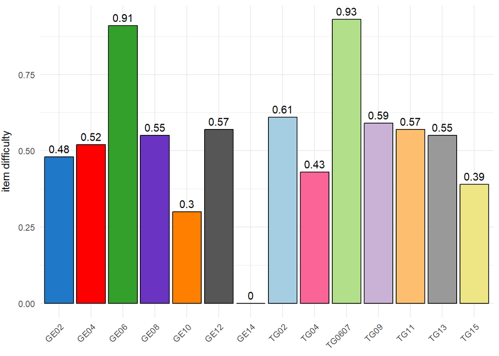

Die Grafik zeigt, dass die allermeisten Fragen nicht so häufig richtig beantwortet wurden, wie bei einer Expertenbefragung zu hoffen ist. Ausnahmen sind die zwei Fragen GE06 und TG0607 (eine Frage im Fragebogen). Diese thematisieren beide das gleiche Konzept *Statistische Modelle*, dieses scheint also eindeutig zu sein. Besonders schlecht beantwortet wurde das Konzept *Datenqualität* mit den Fragen GE14 und TG15. Wir werden später noch einmal alle Fragen mit den dazugehörigen Antwortverteilungen im Detail betrachten.

## Andere Scorevarianten

Schauen wir uns nun noch kurz einmal an, welche durschnittliche Punktzahl bei den anderen beiden Scoringarten erreicht wurde. Da in denen einzelnen Fragen unterschiedliche viele Punkte erreichbar sind, geben wir diese im Verhältnis zur maximal erreichbaren Punktzahl in jeder Frage an.

$$average\:score=\frac{mean_{Score}}{max_{points}}$$

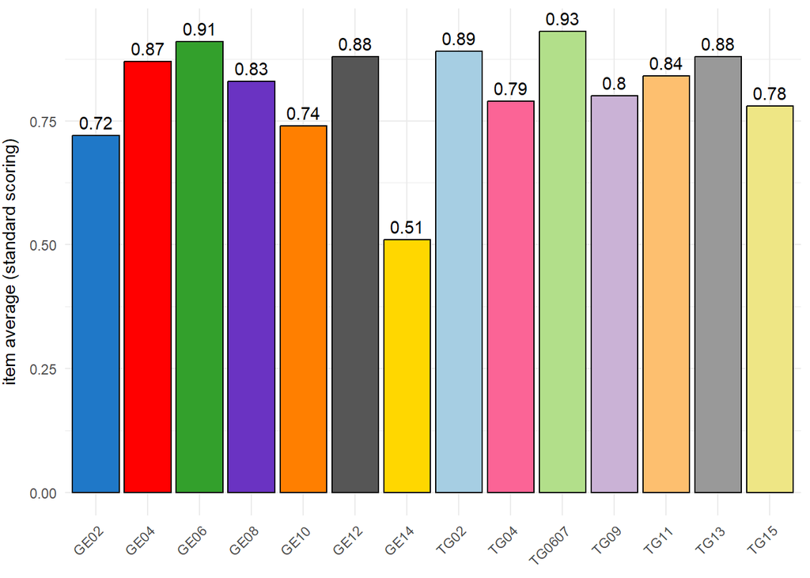

Wir sehen, dass die Experten mit dem Standardverfahren meist über 80% in den Aufgaben erreichen. Auch hier sticht erwartbar wieder Frage GE14 heraus. Interesanterweise erhält Frage TG15, welche ebenfalls von den Experten selten richtig beantwortet wieder, hier deutlich mehr Punkte. Das heißt, im Schnitt wurden hier weniger “Fehler” gemacht.

Betrachten wir nun noch das Formula Scoring mit dem gleichen Vorgehen.

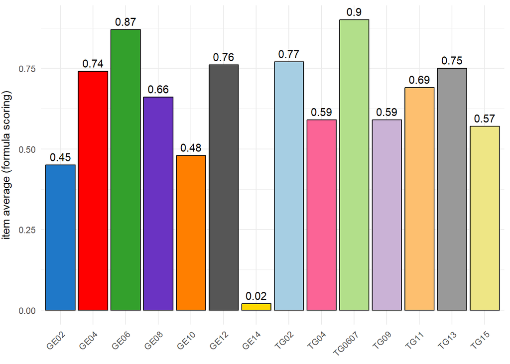

Aufgrund der Maluspunkte sind die Unterschiede zwischen richtig und falsch beantworteten Fragen deutlich stärker, wodurch sich auch das Mittel über alle Befragten verschiebt.

## Vergleich über alle Score Varianten

Schauen wir uns zuletzt nun die durchschnittlichen Scores über alle drei Score Varianten an.

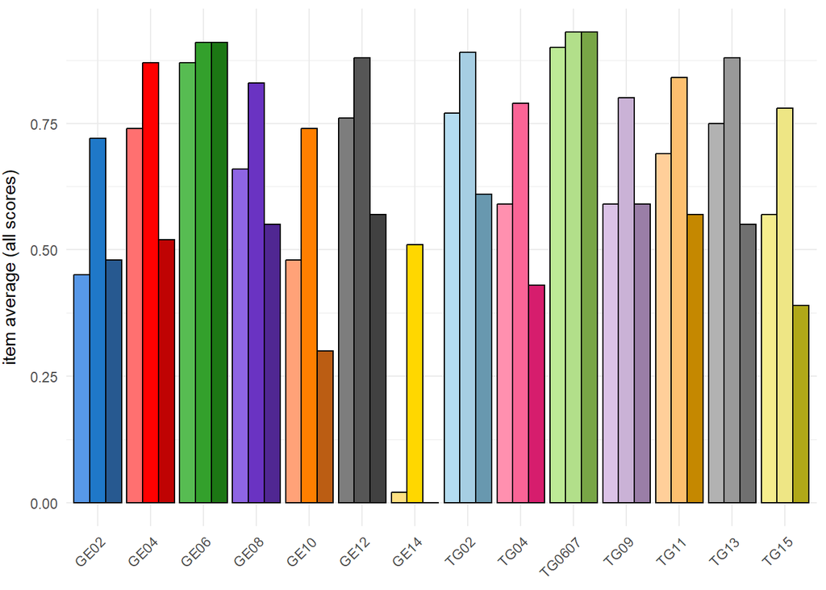

Der linke helle Balken ist das *Formulascoring*, der mittlere Balken das *Standardscoring* und der rechte dunklere Balken die Itemschwierigkeit, also das *Testletscoring*.

# Verständlichkeit der Fragen

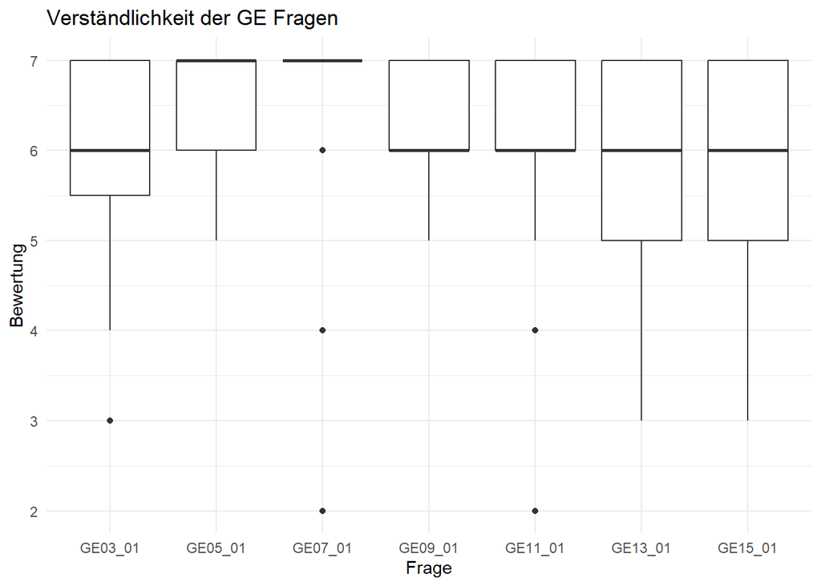

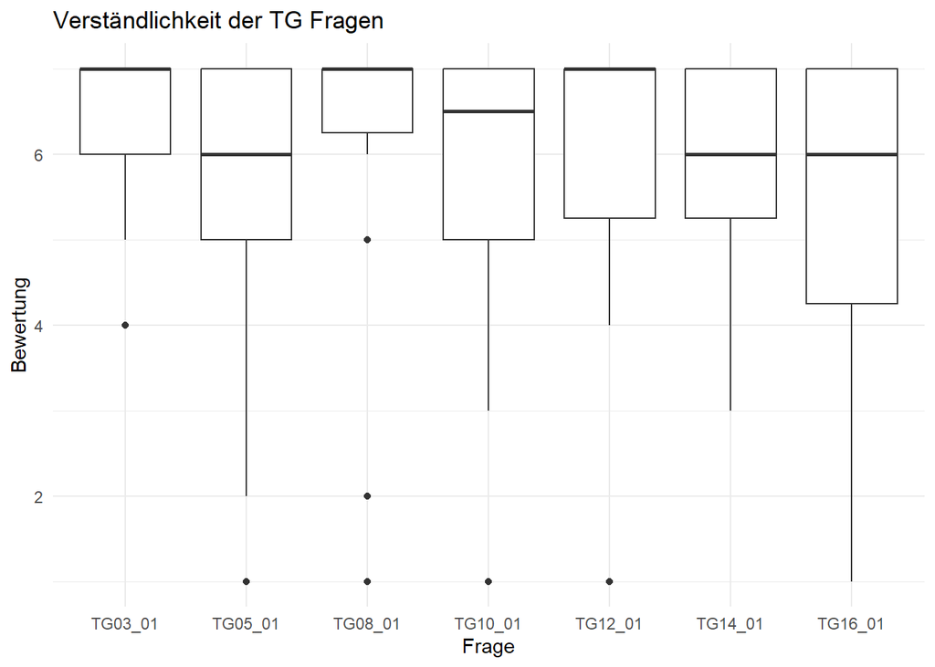

# Vorwissen

Als nächstes wollen wir uns anschauen, welches Vorwissen die Befragten haben und wie sich dieses auf den Gesamtscore auswirkt. Als erstes betrachten wir erst einmal die Verteilung zu den einzelnen Vorwissensfragen. Da es sich um Expertenbefragungen handelt, sollte ein Großteil der Befragten über viel Vorwissen verfügen.

```
##                                                                                        Frage
## 1                                               Ich kenne die grundlegenden Konzepte des ML.
## 11                               Ich habe Erfahrung im Umsetzen von Projekten im Bereich ML.
## 12                                               Ich arbeite bzw. forsche im Bereich des ML.
## 13                                                  Ich kenne den grundlegenden ML-Workflow.
## 14 Ich kann grundlegend einschätzen, wie die Gesichtserkennung beim Smartphone funktioniert.
## 15    Ich kann grundlegend erklären, wie die Gesichtserkennung beim Smartphone funktioniert.
## 16       Ich kann grundlegend einschätzen, wie die Textgenerierung mit ChatGPT funktioniert.
## 17          Ich kann grundlegend erklären, wie die Textgenerierung mit ChatGPT funktioniert.
##    1 2 3  4  5
## 1  1 1 2  6 13
## 11 5 1 5  5  7
## 12 3 3 3  5  9
## 13 2 2 4  5 10
## 14 0 4 3 11  5
## 15 1 4 8  7  3
## 16 0 0 2  9 12
## 17 0 2 6  7  8
```

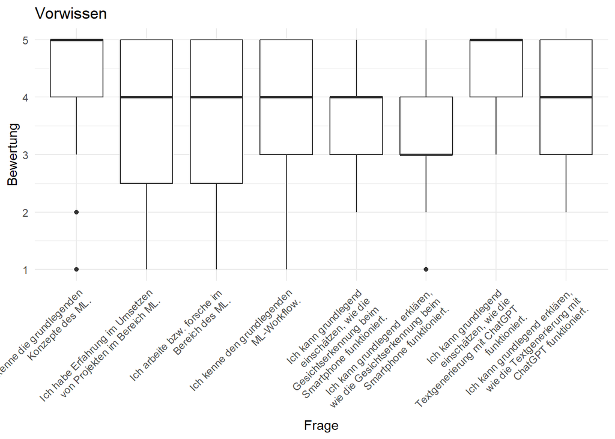

## Korrelation zwischen Vorkenntnissen und Gesamtscore

Als nächsten wollen wir betrachten, inwiefern die selbsteingeschätzen Vorkenntnisse mit dem Gesamtscore korrelieren. Hypothesen:

- Personen, die ihr ML Wissen höher einschätzen, sollten bei einem funktionierenden Test auch eine höhere Gesamtpunktzahl erreichen.
- Personen die mehr Kenntnisse über eine der Technologien haben, sollten bei einem funktionierenden Test auch eine höhere Gesamtpunktzahl erhalten.

Wir verwenden die Rangkorrelation nach Spearman. Da wir verschiedene Varianten haben, die Fragen zu Scoren, bestimmen wir die Korrelationen für jede der drei Scoring Arten.

```
##   Question usedScore Correlation     p_value
## 1  VK03_01  Standard   0.5827988 0.004421280
## 2  VK03_01   Formula   0.5482341 0.008250018
## 3  VK03_01   Testlet   0.5827988 0.004421280
```

Hypothese 1 können wir bestätigen. Tatsächliche zeigt sich eine signifiakte positive Korrelation zwischen der Selbsteinschätzung *“Ich kenne die grundlegenden Konzepte des ML.*” und des Gesamtscores, unabhängig vom Scoring Verfahren. Alle anderen Korrelationen sind zwar auch positiv, jedoch nicht signifikant, weshalb sie hier nicht aufgeführt sind. Unter Umständen benötigen wir hier mehr Teilnehmende um eine signifikante Korrelation nachzuweisen.

# Reliabilität

Als letzte Metrik für den Gesamtscore schauen wir uns die Reliabilität des Fragebogens an.

## Korrelationsmatrix

Schauen wir uns erst einmal die Korrelationen der Fragen untereinander an. Innerhalb einer Anwendung (Gesichtserkennung oder Textgenerierung) sollten die Fragen wenig miteinander korrelieren. Diese würde dafür sprechen, dass die Fragen unabhängig voneinander beantwortet werden können. Ausnahmen bilden hier die Fragen zu den Konzepten *Programmierung* und *Evaluation*, weil für diese bereits im Vorfeld eine Abhängigkeit zu anderen Konzepten erwartet wurde.

Über beide Anwendungen hinweg ist nicht genau klar, wie Fragen zum gleichen Konzept korrelieren sollten. Einerseits fragen sie das gleiche Konzept an, wodurch ein Zusammenhang erwartbar ist. Andererseits ist auch erwartbar, dass aufgrund der unterschiedlichen mentalen Modelle zu den Anwendungen, die Konzepte ganz anders wahrgenommen werden.

Wir betrachten zuerst die Korrelationsmatrizen für die einzelnen Anwendungen. Wir berechnen die Spearman-Korrelation.

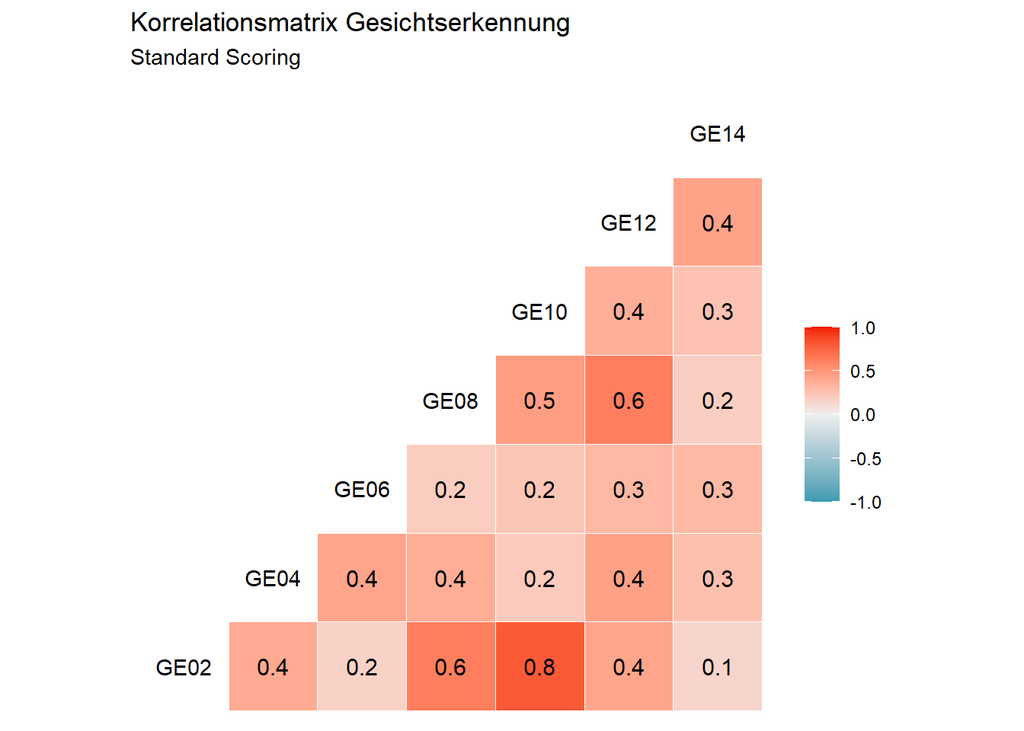

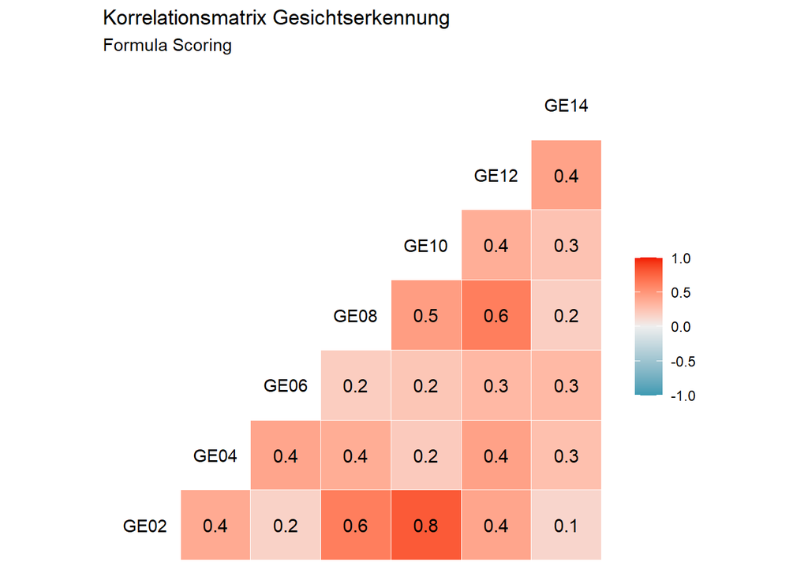

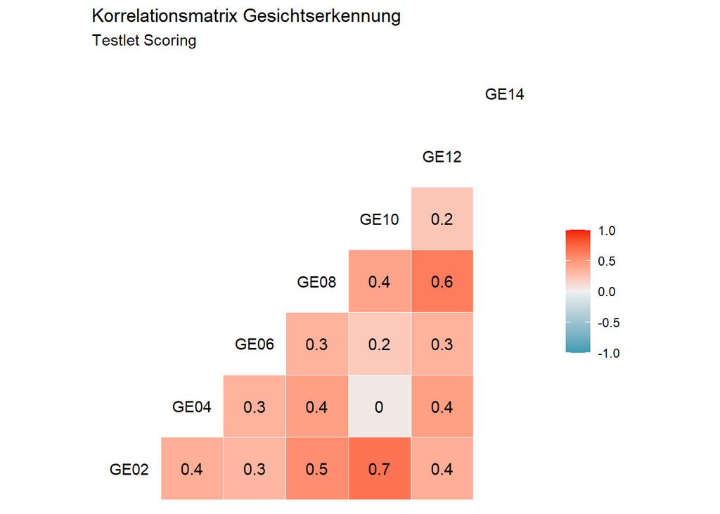

Insgesamt sehen wir, dass Frage GE02 (Konzept *Modellbildung*) sehr stark mit Frage GE10 (Konzept *Programmierung*) korreliert. Auch für das Konzept *Evaluation* (GE12), gibt es eine Abhängigkeit zum Konzept *Zeitpunkt* (GE08).

Schauen wir uns nun analog die Abhängigkeiten bei der Textgenerierung an.

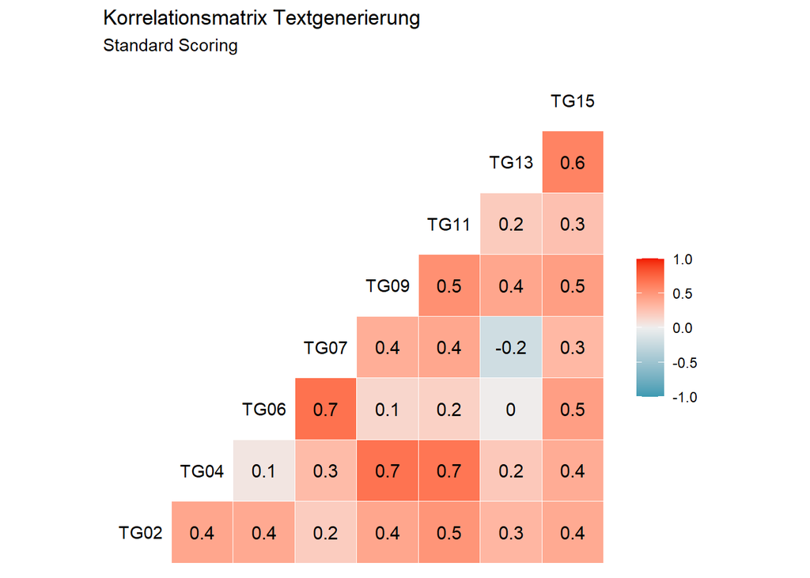

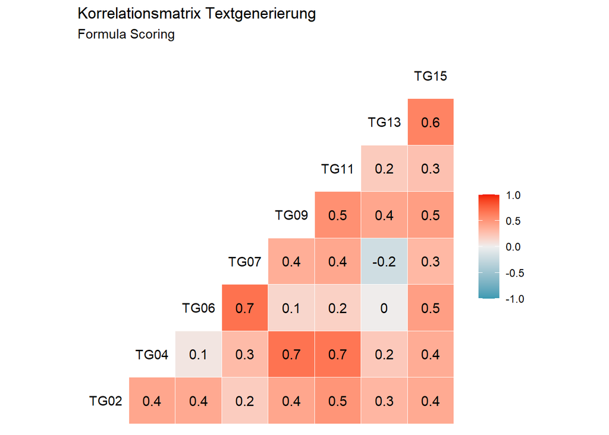

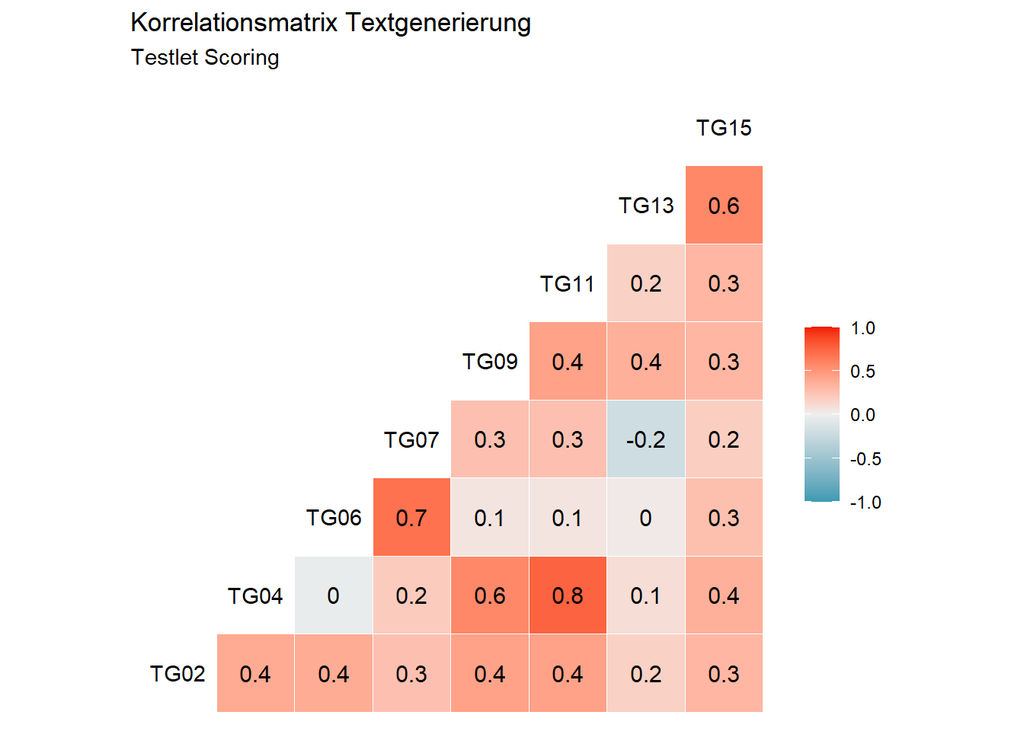

Schauen wir uns nun noch die Korrelationen über alle Fragen an.

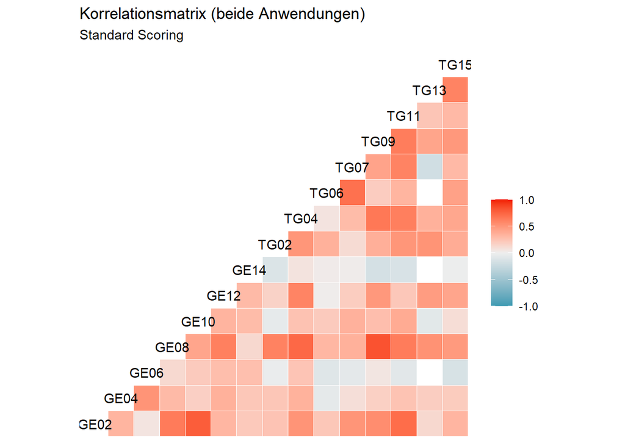

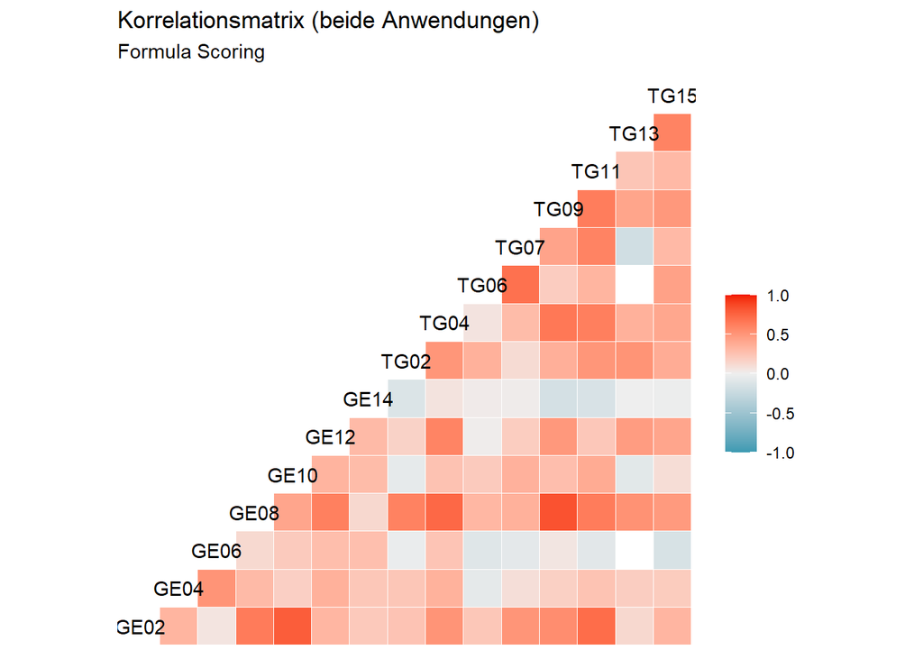

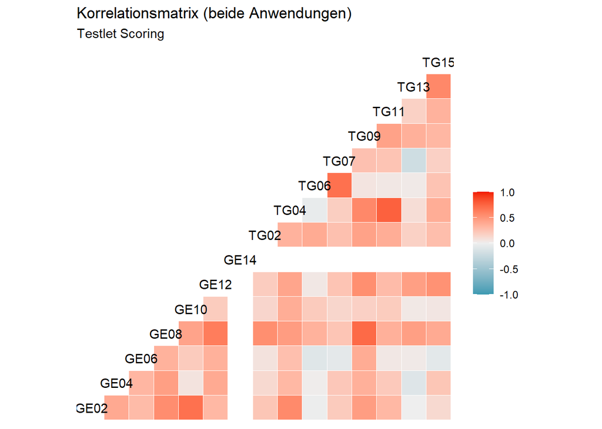

## Cronbachs’ Alpha

Wir bestimmen die interne Testreliabilität nun klassisch mit Cronbachs’ Alpha in Abhängigkeit von den drei Score Varianten. Offene Frage: muss das standardisierte Alpha berechnet werden oder das klassische?

[1] “**Alpha(Standard Scoring):** 0.86”

Cronbachs’ Alpha und Guttman’s Lambda, wenn Item gedropt wird.

|  | raw_alpha | G6(smc) |
| --- | --- | --- |
| GE02 | 0.84 | 0.95 |
| GE04 | 0.86 | 0.96 |
| GE06 | 0.87 | 0.96 |
| GE08 | 0.83 | 0.94 |
| GE10 | 0.86 | 0.95 |
| GE12 | 0.85 | 0.95 |
| GE14 | 0.87 | 0.97 |
| TG02 | 0.85 | 0.96 |
| TG04 | 0.84 | 0.95 |
| TG06 | 0.86 | 0.95 |
| TG07 | 0.85 | 0.95 |
| TG09 | 0.84 | 0.95 |
| TG11 | 0.84 | 0.95 |
| TG13 | 0.86 | 0.96 |
| TG15 | 0.85 | 0.95 |

```
## Number of categories should be increased  in order to count frequencies.
```

[1] “**Alpha (Formula Scoring):** 0.86”

Cronbachs’ Alpha und Guttman’s Lambda, wenn Item gedropt wird.

|  | raw_alpha | G6(smc) |
| --- | --- | --- |
| GE02 | 0.84 | 0.95 |
| GE04 | 0.86 | 0.96 |
| GE06 | 0.86 | 0.96 |
| GE08 | 0.83 | 0.94 |
| GE10 | 0.86 | 0.95 |
| GE12 | 0.85 | 0.95 |
| GE14 | 0.87 | 0.97 |
| TG02 | 0.85 | 0.96 |
| TG04 | 0.84 | 0.95 |
| TG06 | 0.86 | 0.95 |
| TG07 | 0.86 | 0.95 |
| TG09 | 0.84 | 0.95 |
| TG11 | 0.84 | 0.95 |
| TG13 | 0.85 | 0.96 |
| TG15 | 0.85 | 0.95 |

[1] “**Alpha (Testlet Scoring):** 0.86”

Cronbachs’ Alpha und Guttman’s Lambda, wenn Item gedropt wird.

|  | raw_alpha | G6(smc) |
| --- | --- | --- |
| GE02 | 0.84 | 0.95 |
| GE04 | 0.86 | 0.96 |
| GE06 | 0.87 | 0.96 |
| GE08 | 0.83 | 0.94 |
| GE10 | 0.86 | 0.95 |
| GE12 | 0.85 | 0.95 |
| GE14 | 0.87 | 0.97 |
| TG02 | 0.85 | 0.96 |
| TG04 | 0.84 | 0.95 |
| TG06 | 0.86 | 0.95 |
| TG07 | 0.85 | 0.95 |
| TG09 | 0.84 | 0.95 |
| TG11 | 0.84 | 0.95 |
| TG13 | 0.86 | 0.96 |
| TG15 | 0.85 | 0.95 |

# Antwortverteilungen

Nachdem wir uns Metriken basierend auf den Gesamtscores angeschaut haben, wollen wir nun die Fragen im Einzelnen betrachten. Hier interessieren uns vor allem die Verteilung der Antworten.

## Gesichtserkennung

### Modellbildung

[output not shown]

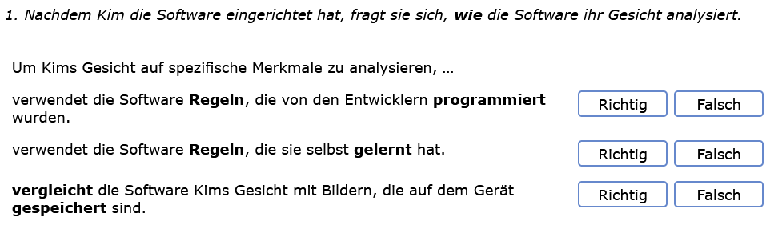

| Frage | Difficulty | Standard | Formula |
| --- | --- | --- | --- |
| GE02 | 0.48 | 0.72 | 0.45 |

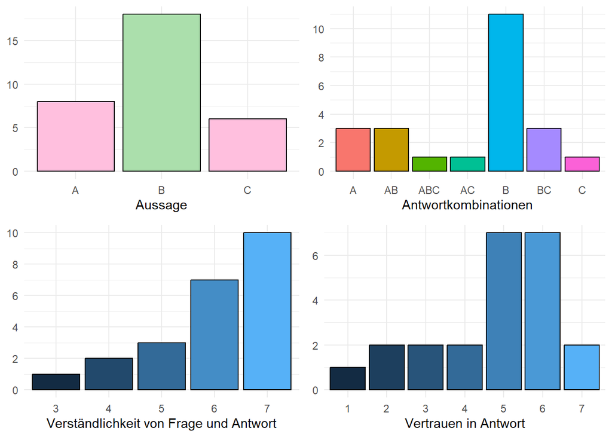

### Datenauswahl

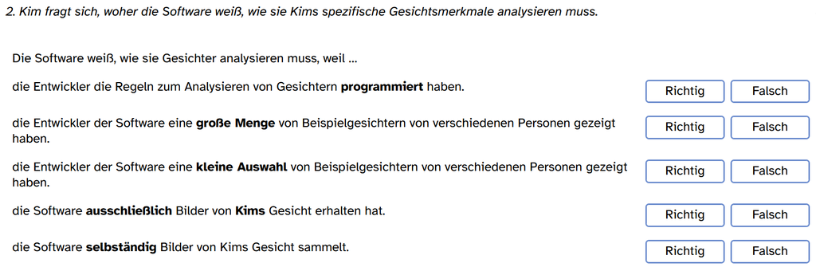

**Datenauswahl**

Die für den ML-Prozess nötigen Daten müssen in einer ausreichenden Menge vorliegen, um daraus statistische Zusammenhänge schließen zu können. Die Entwickler sammeln dazu die benötigten Daten (Messungen, Webcrawler, …) oder, im Fall von verstärkendem Lernen, definieren, welche Daten der Agent erheben und verarbeiten soll. Die Auswahl und Bewertung der benötigten Daten erfolgt demnach durch die Entwickler.

| Frage | Difficulty | Standard | Formula |
| --- | --- | --- | --- |
| GE04 | 0.52 | 0.87 | 0.74 |

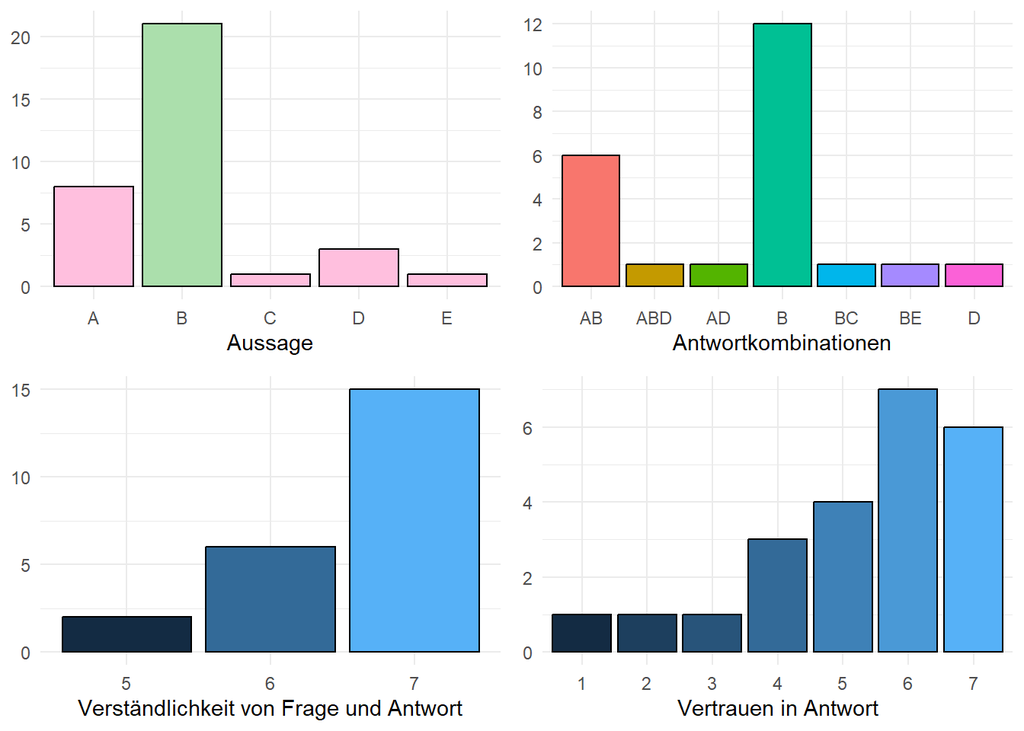

### Statistische Modelle

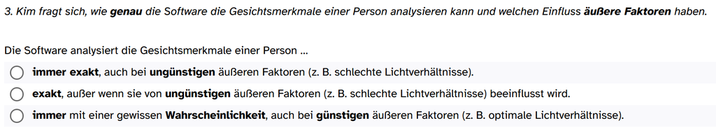

### Zeitpunkt

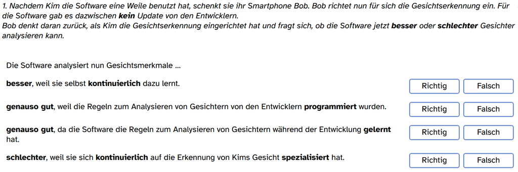

| Frage | Difficulty | Standard | Formula |
| --- | --- | --- | --- |
| GE08 | 0.55 | 0.83 | 0.66 |

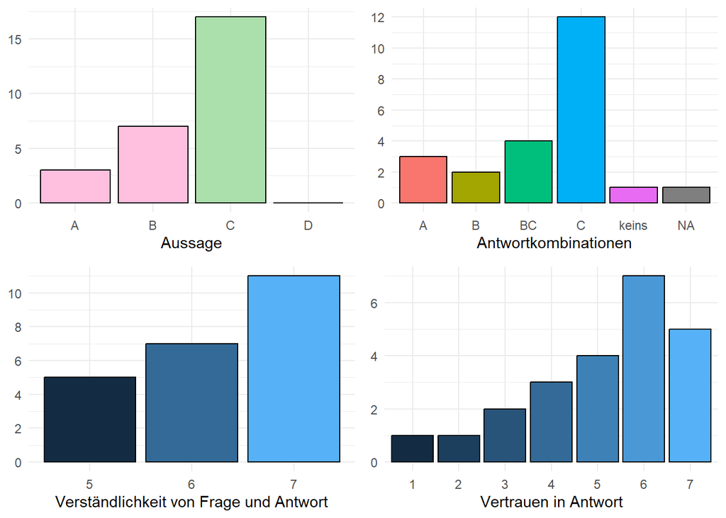

### Programmierung

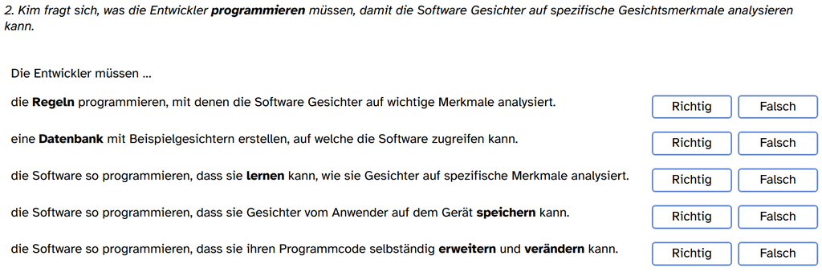

| Frage | Difficulty | Standard | Formula |
| --- | --- | --- | --- |
| GE10 | 0.3 | 0.74 | 0.48 |

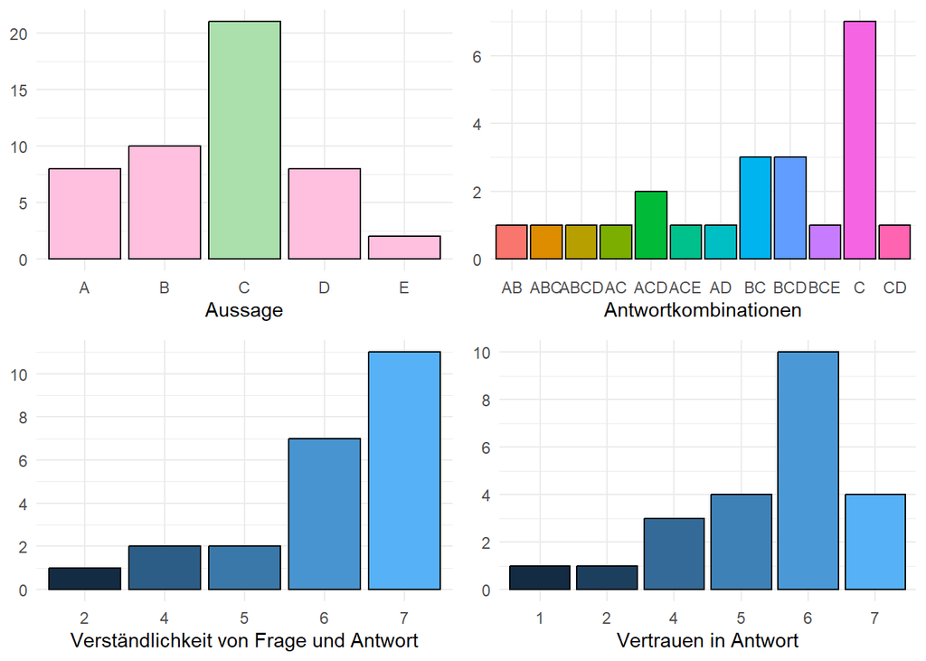

### Evaluation

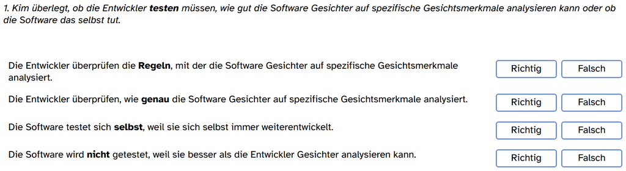

| Frage | Difficulty | Standard | Formula |
| --- | --- | --- | --- |
| GE12 | 0.57 | 0.88 | 0.76 |

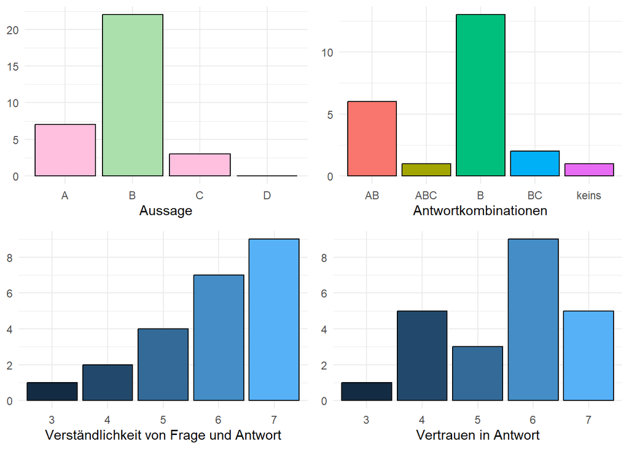

### Datenqualität

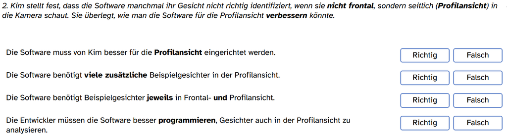

| Frage | Difficulty | Standard | Formula |
| --- | --- | --- | --- |
| GE14 | 0 | 0.51 | 0.02 |

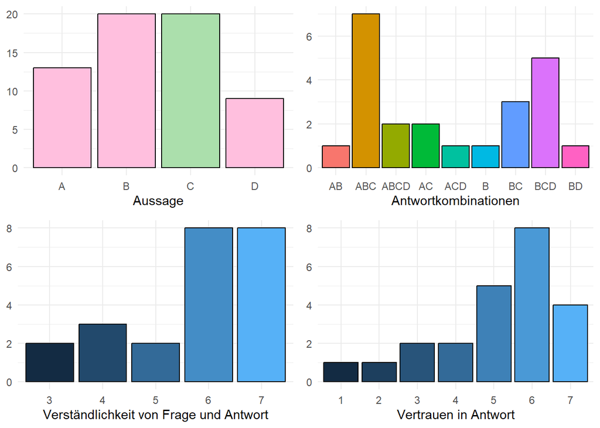